# Dynamic Targeting Exercise: Gain from mixed strategy

James Yu, 6 March 2022

```python
import matplotlib.pyplot as plt
import numpy as np

# some convenient labels
INFLUENTIAL = 1
FOLLOWER = 2
STUBBORN = 3
```

Goal: determine the payoff increase from dynamic targeting.

# Time-variant dynamic system

Using the paper as a basis, let:

$$V_t(x_t) = \max_{r_t} -x_t^\prime Q x_t + \delta V_{t+1}(x_{t+1})$$

Use the transition law of:

$$x_{t+1} = A_{t+1}x_t + B_{t+1}r_t$$

Such that the network first appears in period $t = 1$ and transforms $x_0$ to $x_1$. The network at time $t+1$ then transforms $x_t$ into $x_{t+1}$.

This gives:

$$V_t(x_t) = \max_{r_t} -x_t^\prime Q x_t - r_t^\prime R r_t + \delta V_{t+1}(A_{t+1}x_t + B_{t+1}r_t)$$

Use $V_t(x_t) = -x_t^\prime K_t x_t$ to expand this as:

$$-x_t^\prime K_t x_t = \max_{r_t} -x_t^\prime Q x_t - r_t^\prime R r_t + \delta (A_{t+1}x_t + B_{t+1}r_t)^\prime K_{t+1} (A_{t+1}x_t + B_{t+1}r_t)$$

The first-order condition with respect to $r_t$ gives the following:

$$-(B_{t+1}^\prime K_{t+1} B_{t+1} + \frac{R}{\delta})r_t = B_{t+1}^\prime K_{t+1} A_{t+1} x_t$$

and so we compute $r^*_t$ as $L_t x_t$ where $L_t$ is defined as:

$$L_t = -(B_{t+1}^\prime K_{t+1} B_{t+1} + \frac{R}{\delta})^{-1} B_{t+1}^\prime K_{t+1} A_{t+1}$$

In this sense the strategy $L_t$ is defined by the result $K_{t+1}$ and network $A_{t+1}$, $B_{t+1}$ of the next interval.

This gives rise to the following recursive definition for $K_t$:

$$K_t = Q + \delta A_{t+1}^\prime (K_{t+1} - K_{t+1} B_{t+1}(B_{t+1}^\prime K_{t+1} B_{t+1} + \frac{R}{\delta})^{-1} B_{t+1}^\prime K_{t+1})A_{t+1}$$

```python
def solve_dynamic(order, x_0):
    # order: a vector of length T containing the network matrices from period t = 1 to t = T

    R = 0
    delta = 0.9
    T = 15 # will zoom this in later in the notebook

    A_basis_1 = np.array([
        [0.6 * 0.99, 0.2*0.99, 0.2*0.99],
        [0.5, 0.5, 0.0],
        [0.2, 0.0, 0.8]
    ], ndmin = 2)

    A_basis_2 = np.array([
        [0.6, 0.2, 0.2],
        [0.5, 0.5, 0.0],
        [0.2*0.99, 0.0*0.99, 0.8*0.99]
    ], ndmin = 2)

    A = [A_basis_1, A_basis_2]

    B_basis_1 = np.array([
        [0.01],
        [0.0],
        [0.0]
    ], ndmin = 2)

    B_basis_2 = np.array([
        [0.0],
        [0.0],
        [0.01]
    ], ndmin = 2)

    B = [B_basis_1, B_basis_2]

    n = x_0.size
    Q = (1 / n) * np.identity(n)
    K_t = Q
    K_sequence = [Q]

    # iterate backwards to construct K_t from period T-1 to period 0
    # let K_T = Q
    # K_0 is not used in the computation of L_t as L_0 uses K_1 but I compute it anyway
    for t in range(T): # iterate over T periods from T-1 to 0
        K_t = delta * A[order[(T-t)-1]].T @ (K_t - K_t @ B[order[(T-t)-1]] @ np.linalg.inv(B[order[(T-t)-1]].T @ K_t @ B[order[(T-t)-1]] + R / delta) @ B[order[(T-t)-1]].T @ K_t) @ A[order[(T-t)-1]] + Q
        K_sequence.insert(0, K_t)

    x_t = x_0
    r_ts = []
    payoff = 0
    payoffs = []
    x_ts = [x_0]

    # iterate forwards to construct opinion vectors and payoffs from t = 1 to t = T
    # compute L_t from t = 0 to t = T-1
    for t in range(T):
        # here order[t] is the selected A or B for period t+1 since the order vector, at index zero, contains t = 1
        L_t = -(np.linalg.inv(B[order[t]].T @ K_sequence[t+1] @ B[order[t]] + R / delta) @ B[order[t]].T @ K_sequence[t] @ A[order[t]])
        r_t = L_t @ x_t
        r_ts.append(r_t.item())
        payoff += (-1 * delta**t * (x_t.T @ Q @ x_t)).item() + (-1 * delta**t * (R * r_t**2)).item()
        payoffs.append(payoff)
        # again, order[t] is the network matrix at time t+1
        x_t_new = A[order[t]] @ x_t + B[order[t]] @ r_t
        x_ts.append(x_t_new)
        x_t = x_t_new

    return payoff, payoffs, r_ts
```

```python
x_0 = np.array([[-10], [7], [20]], ndmin = 2)
order = [0 for i in range(15)] # always target agent 1
total_payoff, _, _ = solve_dynamic(order, x_0)
total_payoff
```

```
-315.0966740323721
```

```python
order = [1 for i in range(15)] # always target agent 3
total_payoff, _, _ = solve_dynamic(order, x_0)
total_payoff
```

```
-184.82791745856824
```

```python
from itertools import product
from collections import defaultdict
saved_order = defaultdict(list)
for i, order in enumerate(product(range(2), repeat = 15)):
    if i % 10000 == 0:
        print(i)
    total_payoff, _, _ = solve_dynamic(order, x_0)
    saved_order[total_payoff].append(order)

saved_order[max(saved_order.keys())]
```

```
0
10000
20000
30000
```

```
[(1, 1, 0, 0, 0, 0, 1, 0, 0, 0, 1, 0, 0, 1, 0)]
```

```python
klist = list(sorted(saved_order.keys(), key = lambda x: -x))
for key in klist[:20]:
    print(key)
    print(saved_order[key])
```

```
-184.41201092812818
[(1, 1, 0, 0, 0, 0, 1, 0, 0, 0, 1, 0, 0, 1, 0)]
-184.41201092825654
[(1, 1, 0, 0, 0, 0, 1, 0, 0, 0, 1, 0, 0, 1, 1)]
-184.4120109304836
[(1, 1, 0, 0, 0, 0, 1, 0, 0, 0, 1, 0, 0, 0, 1)]
-184.41201093165873
[(1, 1, 0, 0, 0, 0, 1, 0, 0, 0, 1, 0, 0, 0, 0)]
-184.41201093381977
[(1, 1, 0, 0, 0, 0, 1, 0, 0, 0, 1, 0, 1, 0, 1)]
-184.41201093431022
[(1, 1, 0, 0, 0, 0, 1, 0, 0, 0, 1, 0, 1, 0, 0)]
-184.41201094272182
[(1, 1, 0, 0, 0, 0, 1, 0, 0, 0, 1, 0, 1, 1, 0)]
-184.4120109448664
[(1, 1, 0, 0, 0, 0, 1, 0, 0, 0, 1, 0, 1, 1, 1)]
-184.412010999514
[(1, 1, 0, 0, 0, 0, 1, 0, 0, 1, 0, 0, 1, 0, 1)]
-184.4120109998336
[(1, 1, 0, 0, 0, 0, 1, 0, 0, 1, 0, 0, 1, 0, 0)]
-184.41201100014143
[(1, 1, 0, 0, 0, 0, 1, 0, 0, 1, 0, 0, 0, 1, 0)]
-184.41201100027197
[(1, 1, 0, 0, 0, 0, 1, 0, 0, 1, 0, 0, 0, 1, 1)]
-184.41201100274642
[(1, 1, 0, 0, 0, 0, 1, 0, 0, 1, 0, 0, 0, 0, 1)]
-184.4120110032804
[(1, 1, 0, 0, 0, 0, 1, 0, 0, 1, 0, 0, 1, 1, 0)]
-184.41201100408625
[(1, 1, 0, 0, 0, 0, 1, 0, 0, 1, 0, 0, 1, 1, 1)]
-184.4120110041255
[(1, 1, 0, 0, 0, 0, 1, 0, 0, 1, 0, 0, 0, 0, 0)]
-184.4120110045968
[(1, 1, 0, 0, 0, 0, 1, 0, 0, 0, 1, 1, 0, 0, 1)]
-184.41201100463053
[(1, 1, 0, 0, 0, 0, 1, 0, 0, 0, 1, 1, 0, 0, 0)]
-184.4120110079895
[(1, 1, 0, 0, 0, 0, 1, 0, 0, 0, 1, 1, 0, 1, 0)]
-184.41201100964497
[(1, 1, 0, 0, 0, 0, 1, 0, 0, 0, 1, 1, 0, 1, 1)]
```

1 means in the i-th period, the third agent was targeted.

0 means in the i-th period, the first agent was targeted.

Note there are slightly more instances of targeting agent three in this case - the only change compared to before, however, is that $\delta = 0.9$ instead of $\delta = 0.5$.

### Plot the results:

```
-184.41201092812818
```

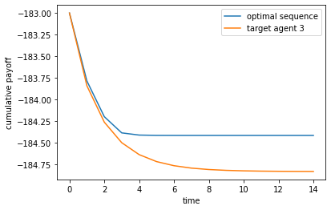

```python
optimal_sequence = (1, 1, 0, 0, 0, 0, 1, 0, 0, 0, 1, 0, 0, 1, 0)
target_three = (1, 1, 1, 1, 1, 1, 1, 1, 1, 1, 1, 1, 1, 1, 1)
payoff, payoffs_optimal, rts_optimal = solve_dynamic(optimal_sequence, x_0)
_, payoffs_three, rts_target3 = solve_dynamic(target_three, x_0)
print(payoff)
plt.plot(range(15), payoffs_optimal, label = "optimal sequence")
plt.plot(range(15), payoffs_three, label = "target agent 3")
plt.legend()
plt.xlabel("time")
plt.ylabel("cumulative payoff")
plt.show()
```

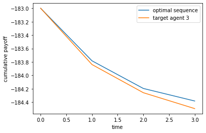

```python
plt.plot(range(4), payoffs_optimal[:4], label = "optimal sequence")
plt.plot(range(4), payoffs_three[:4], label = "target agent 3")
plt.legend()
plt.xlabel("time")
plt.ylabel("cumulative payoff")
plt.show()
```

Note that payoff increases immediately, even though the same target is used in both strategies for the first 2 periods.

```python
print(rts_optimal) # switching case messages
```

[output not shown]

```python
print(rts_target3) # static case messages
```

```
[-1342.7347478437543, 12.920870581838496, 11.979649367919682, 10.027187540914577, 8.17211685776021, 6.607049257779367, 5.322980198622629, 4.274847456090741, 3.4170301972609547, 2.709684044649542, 2.1187073328195143, 1.6145153396907483, 1.1713048339959873, 0.7708006603770096, 0.43365248548813634]
```

```
-184.41214014630725
```

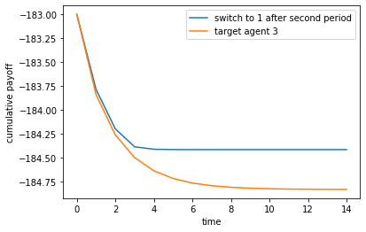

```python
immediate_switch = (1, 1, 0, 0, 0, 0, 0, 0, 0, 0, 0, 0, 0, 0, 0)
target_three = (1, 1, 1, 1, 1, 1, 1, 1, 1, 1, 1, 1, 1, 1, 1)
payoff, payoffs_switch, _ = solve_dynamic(immediate_switch, x_0)
print(payoff)
_, payoffs_three, _ = solve_dynamic(target_three, x_0)
plt.plot(range(15), payoffs_switch, label = "switch to 1 after second period")
plt.plot(range(15), payoffs_three, label = "target agent 3")
plt.legend()
plt.xlabel("time")
plt.ylabel("cumulative payoff")
plt.show()
```

```python
-184.41201092812818 - (-184.41214014630725) # fully optimal, higher payoff, minus less optimal, single-switch case payoff
```

```
0.00012921817906885735
```

Note that the difference in payoff between the fully optimal case and this simple switch case is small compared to their magnitudes, which means the single-switch strategy still performs extremely well.

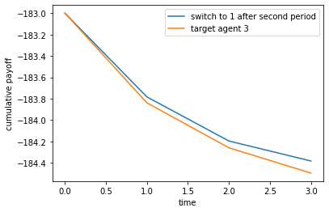

```python
plt.plot(range(4), payoffs_switch[:4], label = "switch to 1 after second period")
plt.plot(range(4), payoffs_three[:4], label = "target agent 3")
plt.legend()
plt.xlabel("time")
plt.ylabel("cumulative payoff")
plt.show()
```

```
-184.58648086209436
```

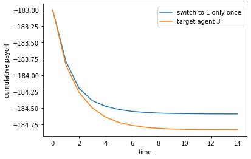

```python
brief_switch = (1, 1, 0, 1, 1, 1, 1, 1, 1, 1, 1, 1, 1, 1, 1)
target_three = (1, 1, 1, 1, 1, 1, 1, 1, 1, 1, 1, 1, 1, 1, 1)
payoff, payoffs_brief_switch, _ = solve_dynamic(brief_switch, x_0)
print(payoff)
_, payoffs_three, _ = solve_dynamic(target_three, x_0)
plt.plot(range(15), payoffs_brief_switch, label = "switch to 1 only once")
plt.plot(range(15), payoffs_three, label = "target agent 3")
plt.legend()
plt.xlabel("time")
plt.ylabel("cumulative payoff")
plt.show()
```

```
-184.6755898362596
```

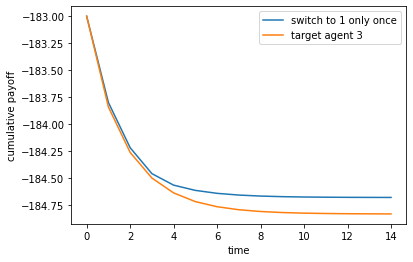

```python
brief_switch = (1, 1, 1, 0, 1, 1, 1, 1, 1, 1, 1, 1, 1, 1, 1)
target_three = (1, 1, 1, 1, 1, 1, 1, 1, 1, 1, 1, 1, 1, 1, 1)
payoff, payoffs_brief_switch, _ = solve_dynamic(brief_switch, x_0)
print(payoff)
_, payoffs_three, _ = solve_dynamic(target_three, x_0)
plt.plot(range(15), payoffs_brief_switch, label = "switch to 1 only once")
plt.plot(range(15), payoffs_three, label = "target agent 3")
plt.legend()
plt.xlabel("time")
plt.ylabel("cumulative payoff")
plt.show()
```

```
-184.82789247671602
-184.82791745856824
2.4981852220662404e-05
```

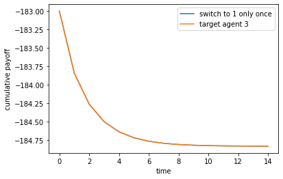

```python
brief_switch = (1, 1, 1, 1, 1, 1, 1, 1, 1, 1, 1, 1, 1, 1, 0)
target_three = (1, 1, 1, 1, 1, 1, 1, 1, 1, 1, 1, 1, 1, 1, 1)
payoff, payoffs_brief_switch, _ = solve_dynamic(brief_switch, x_0)
print(payoff)
payoff2, payoffs_three, _ = solve_dynamic(target_three, x_0)
print(payoff2)
print(payoff - payoff2)
plt.plot(range(15), payoffs_brief_switch, label = "switch to 1 only once")
plt.plot(range(15), payoffs_three, label = "target agent 3")
plt.legend()
plt.xlabel("time")
plt.ylabel("cumulative payoff")
plt.show()
```

Even if you target agent 1 for just one period, payoff increases.

```
-195.48643316975463
```

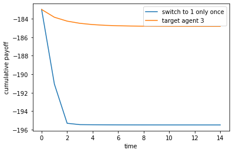

```python
brief_switch = (1, 0, 1, 1, 1, 1, 1, 1, 1, 1, 1, 1, 1, 1, 1)
target_three = (1, 1, 1, 1, 1, 1, 1, 1, 1, 1, 1, 1, 1, 1, 1)
payoff, payoffs_brief_switch, _ = solve_dynamic(brief_switch, x_0)
print(payoff)
_, payoffs_three, _ = solve_dynamic(target_three, x_0)
plt.plot(range(15), payoffs_brief_switch, label = "switch to 1 only once")
plt.plot(range(15), payoffs_three, label = "target agent 3")
plt.legend()
plt.xlabel("time")
plt.ylabel("cumulative payoff")
plt.show()
```

However, if you target agent 1 in the transition from $t = 1$ to $t = 2$, it is no longer optimal.

```
-244.77086697564178
```

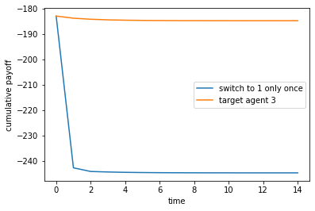

```python
brief_switch = (0, 1, 1, 1, 1, 1, 1, 1, 1, 1, 1, 1, 1, 1, 1)
target_three = (1, 1, 1, 1, 1, 1, 1, 1, 1, 1, 1, 1, 1, 1, 1)
payoff, payoffs_brief_switch, _ = solve_dynamic(brief_switch, x_0)
print(payoff)
_, payoffs_three, _ = solve_dynamic(target_three, x_0)
plt.plot(range(15), payoffs_brief_switch, label = "switch to 1 only once")
plt.plot(range(15), payoffs_three, label = "target agent 3")
plt.legend()
plt.xlabel("time")
plt.ylabel("cumulative payoff")
plt.show()
```

A similar result if you begin by targeting agent 1.

## What about the second switch?

```
-184.41214014630725
```

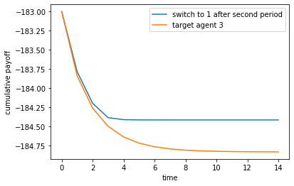

```python
immediate_switch = (1, 1, 0, 0, 0, 0, 0, 0, 0, 0, 0, 0, 0, 0, 0)
target_three = (1, 1, 1, 1, 1, 1, 1, 1, 1, 1, 1, 1, 1, 1, 1)
payoff, payoffs_switch, _ = solve_dynamic(immediate_switch, x_0)
print(payoff)
_, payoffs_three, _ = solve_dynamic(target_three, x_0)
plt.plot(range(15), payoffs_switch, label = "switch to 1 after second period")
plt.plot(range(15), payoffs_three, label = "target agent 3")
plt.legend()
plt.xlabel("time")
plt.ylabel("cumulative payoff")
plt.show()
```

```
-184.41215153052772
```

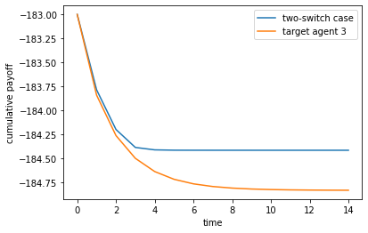

```python
switch_back = (1, 1, 0, 0, 0, 0, 1, 1, 1, 1, 1, 1, 1, 1, 1)
target_three = (1, 1, 1, 1, 1, 1, 1, 1, 1, 1, 1, 1, 1, 1, 1)
payoff2, payoffs_switch, _ = solve_dynamic(switch_back, x_0)
print(payoff2)
_, payoffs_three, _ = solve_dynamic(target_three, x_0)
plt.plot(range(15), payoffs_switch, label = "two-switch case")
plt.plot(range(15), payoffs_three, label = "target agent 3")
plt.legend()
plt.xlabel("time")
plt.ylabel("cumulative payoff")
plt.show()
```

```python
payoff - payoff2
```

```
1.1384220471200024e-05
```

```
-184.41318314040313
```

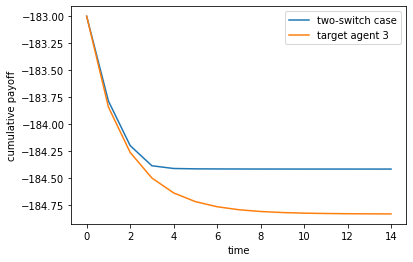

```python
switch_back = (1, 1, 0, 0, 0, 1, 1, 1, 1, 1, 1, 1, 1, 1, 1) # switch earlier
target_three = (1, 1, 1, 1, 1, 1, 1, 1, 1, 1, 1, 1, 1, 1, 1)
payoff3, payoffs_switch, _ = solve_dynamic(switch_back, x_0)
print(payoff3)
_, payoffs_three, _ = solve_dynamic(target_three, x_0)
plt.plot(range(15), payoffs_switch, label = "two-switch case")
plt.plot(range(15), payoffs_three, label = "target agent 3")
plt.legend()
plt.xlabel("time")
plt.ylabel("cumulative payoff")
plt.show()
```

```python
payoff3 - payoff2
```

```
-0.001031609875411732
```

```python
payoff3 - payoff
```

```
-0.001042994095882932
```

This strategy does worse than both the single and original double-switch cases, so switching early does not work. What about switching later?

```
-184.41207083055687
```

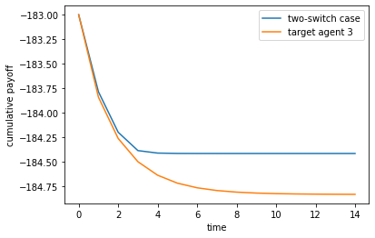

```python
switch_back = (1, 1, 0, 0, 0, 0, 0, 1, 1, 1, 1, 1, 1, 1, 1) # switch later
target_three = (1, 1, 1, 1, 1, 1, 1, 1, 1, 1, 1, 1, 1, 1, 1)
payoff4, payoffs_switch, _ = solve_dynamic(switch_back, x_0)
print(payoff4)
_, payoffs_three, _ = solve_dynamic(target_three, x_0)
plt.plot(range(15), payoffs_switch, label = "two-switch case")
plt.plot(range(15), payoffs_three, label = "target agent 3")
plt.legend()
plt.xlabel("time")
plt.ylabel("cumulative payoff")
plt.show()
```

```python
payoff4 - payoff2
```

```
8.06999708515832e-05
```

```python
payoff4 - payoff
```

```
6.931575038038318e-05
```

This appears to do better, but again, these are all very marginal improvements.